# Word Association RT First Look

Stan West

2025-02-28

Ideas in the lab have been circulating around an idea of “semantic warping”, or the context-driven shifting of semantic weights that make concepts related to the context more available. Below, we describe a study investigating how response times to association generation may differ between conditions where you are given a coherent context to guide associative behavior versus explicit rules as to what kinds of responses are appropriate.

## Condition completion

Target sample size is 30 per condition

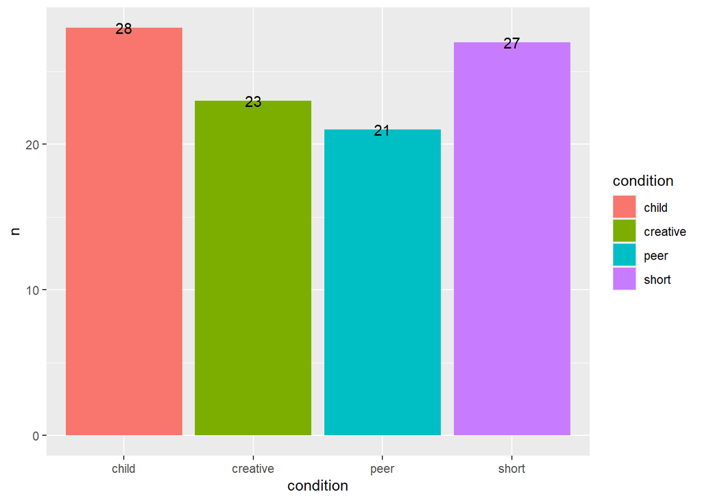

# Participant-wise behavior over cues

### Regressing blank response cues with Prevalence. Removing responses faster than 150 ms and anything further than 3SDs from the participant-wise mean

This was accomplished by filtering out response latencies less than 150ms, grouping by participant and computing z-scores, and filtering out responses that are more than three standard deviations away from the participant means. I then plot the cues in terms of their Prevalence in the MOESM database and their missingness in our response set.

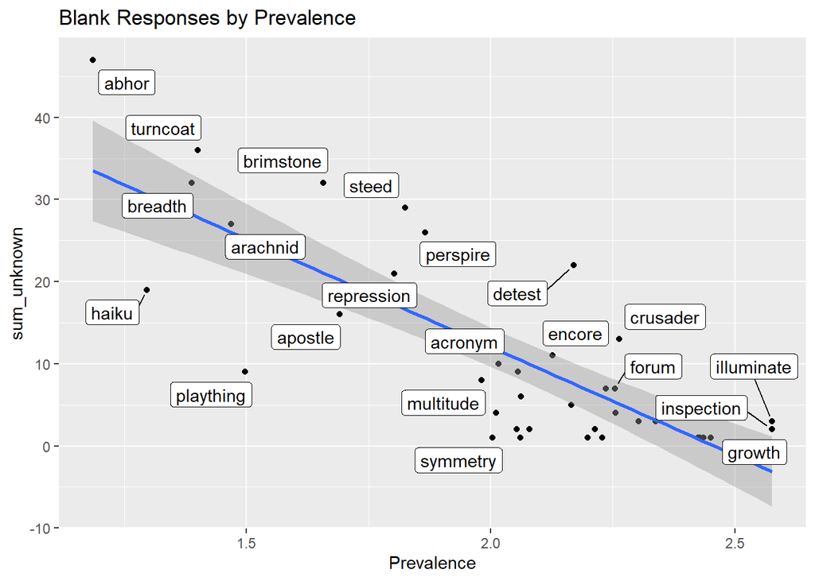

### Participant Z-scored response time by cue. In descending order of number of missing responses. Same procedure as above, but did not filter on standard deviations from the particpant means.

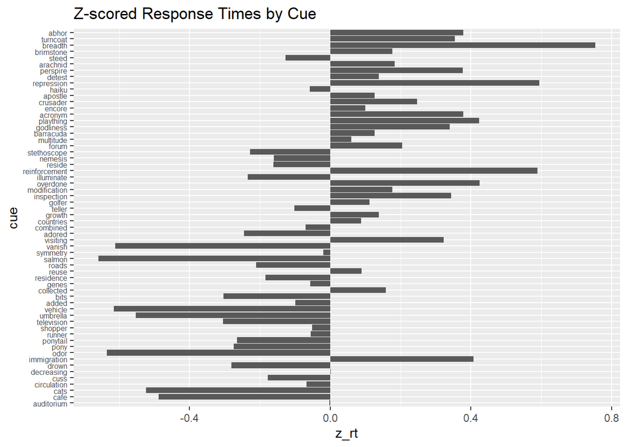

| cue | sum_unknown |
| --- | --- |
| abhor | 47 |
| turncoat | 36 |
| breadth | 32 |
| brimstone | 32 |
| steed | 29 |
| arachnid | 27 |
| perspire | 26 |
| detest | 22 |
| repression | 21 |
| haiku | 19 |
| apostle | 16 |
| crusader | 13 |
| encore | 11 |
| acronym | 10 |
| plaything | 9 |
| barracuda | 9 |
| multitude | 8 |
| godliness | 7 |
| forum | 7 |
| stethoscope | 6 |
| nemesis | 5 |
| reinforcement | 4 |
| reside | 4 |
| illuminate | 3 |
| overdone | 3 |
| modification | 3 |
| teller | 2 |
| growth | 2 |
| inspection | 2 |
| countries | 2 |
| golfer | 2 |
| combined | 2 |
| visiting | 1 |
| collected | 1 |
| roads | 1 |
| salmon | 1 |
| added | 1 |
| adored | 1 |
| bits | 1 |
| symmetry | 1 |
| vanish | 1 |
| genes | 1 |
| residence | 1 |
| reuse | 1 |